# Ford GoBikes System Data Analysis

# Data cleaning

```python
df.drop(columns=['rental_access_method'], inplace=True)
```

```python
df.isnull().sum()
```

```
duration_sec                    0
start_time                      0
end_time                        0
start_station_id            80734
start_station_name          80133
start_station_latitude          0
start_station_longitude         0
end_station_id              82902
end_station_name            82350
end_station_latitude            0
end_station_longitude           0
bike_id                         0
user_type                       0
bike_share_for_all_trip    243259
dtype: int64
```

```python
df.drop(columns=['bike_share_for_all_trip'], inplace=True)
```

```python
df.dropna(inplace=True)
```

```python
df.isnull().sum()
```

```
duration_sec               0
start_time                 0
end_time                   0
start_station_id           0
start_station_name         0
start_station_latitude     0
start_station_longitude    0
end_station_id             0
end_station_name           0
end_station_latitude       0
end_station_longitude      0
bike_id                    0
user_type                  0
dtype: int64
```

```python
df.info(null_counts = True)
```

```
<class 'pandas.core.frame.DataFrame'>
Int64Index: 2407259 entries, 0 to 2506660
Data columns (total 13 columns):
 #   Column                   Non-Null Count    Dtype
---  ------                   --------------    -----
 0   duration_sec             2407259 non-null  int64
 1   start_time               2407259 non-null  object
 2   end_time                 2407259 non-null  object
 3   start_station_id         2407259 non-null  float64
 4   start_station_name       2407259 non-null  object
 5   start_station_latitude   2407259 non-null  float64
 6   start_station_longitude  2407259 non-null  float64
 7   end_station_id           2407259 non-null  float64
 8   end_station_name         2407259 non-null  object
 9   end_station_latitude     2407259 non-null  float64
 10  end_station_longitude    2407259 non-null  float64
 11  bike_id                  2407259 non-null  int64
 12  user_type                2407259 non-null  object
dtypes: float64(6), int64(2), object(5)
memory usage: 257.1+ MB
```

```python
df['start_time']= pd.to_datetime(df['start_time'])
df['start_month']=df['start_time'].dt.strftime('%B')
df['start_day_of_week']=df['start_time'].dt.strftime('%a')
df['start_hour_of_day']=df['start_time'].dt.hour
df['end_time']= pd.to_datetime(df['end_time'])
df['end_month']=df['end_time'].dt.strftime('%B')
df['end_day_of_week']=df['end_time'].dt.strftime('%a')
df['end_hour_of_day']=df['end_time'].dt.hour
```

```python
df.head()
```

|  | duration_sec | start_time | end_time | start_station_id | start_station_name | start_station_latitude | start_station_longitude | end_station_id | end_station_name | end_station_latitude | end_station_longitude | bike_id | user_type | start_month | start_day_of_week | start_hour_of_day | end_month | end_day_of_week | end_hour_of_day |
| --- | --- | --- | --- | --- | --- | --- | --- | --- | --- | --- | --- | --- | --- | --- | --- | --- | --- | --- | --- |
| 0 | 80825 | 2019-01-31 17:57:44.613 | 2019-02-01 16:24:49.864 | 229.0 | Foothill Blvd at 42nd Ave | 37.775745 | -122.213037 | 196.0 | Grand Ave at Perkins St | 37.808894 | -122.256460 | 4861 | Subscriber | January | Thu | 17 | February | Fri | 16 |
| 1 | 65900 | 2019-01-31 20:58:33.886 | 2019-02-01 15:16:54.173 | 4.0 | Cyril Magnin St at Ellis St | 37.785881 | -122.408915 | 134.0 | Valencia St at 24th St | 37.752428 | -122.420628 | 5506 | Subscriber | January | Thu | 20 | February | Fri | 15 |
| 2 | 62633 | 2019-01-31 18:06:52.924 | 2019-02-01 11:30:46.530 | 245.0 | Downtown Berkeley BART | 37.870139 | -122.268422 | 157.0 | 65th St at Hollis St | 37.846784 | -122.291376 | 2717 | Customer | January | Thu | 18 | February | Fri | 11 |
| 3 | 44680 | 2019-01-31 19:46:09.719 | 2019-02-01 08:10:50.318 | 85.0 | Church St at Duboce Ave | 37.770083 | -122.429156 | 53.0 | Grove St at Divisadero | 37.775946 | -122.437777 | 4557 | Customer | January | Thu | 19 | February | Fri | 8 |
| 4 | 60709 | 2019-01-31 14:19:01.541 | 2019-02-01 07:10:51.065 | 16.0 | Steuart St at Market St | 37.794130 | -122.394430 | 28.0 | The Embarcadero at Bryant St | 37.787168 | -122.388098 | 2100 | Customer | January | Thu | 14 | February | Fri | 7 |

```python
import math
from math import radians, sin, cos, acos
def distance(origin, destination):
    lat1, long1 = origin
    lat2, long2 = destination
    radius = 6371 # this is in kms
    dlat = math.radians(lat2 - lat1)
    dlong = math.radians(long2 - long1)
    x = (math.sin(dlat / 2) * math.sin(dlat / 2) + math.cos(math.radians(lat1))
         * math.cos(math.radians(lat2)) * math.sin(dlong / 2) * math.sin(dlong / 2))
    y = 2 * math.atan2(math.sqrt(x), math.sqrt(1 - x))
    z = radius * y
    return z
```

```python
df['distance_km'] = df.apply(lambda x: distance((x['start_station_latitude'], x['start_station_longitude']), (x['end_station_latitude'], x['end_station_longitude'])), axis=1)
```

```python
df.head()
```

|  | duration_sec | start_time | end_time | start_station_id | start_station_name | start_station_latitude | start_station_longitude | end_station_id | end_station_name | end_station_latitude | end_station_longitude | bike_id | user_type | start_month | start_day_of_week | start_hour_of_day | end_month | end_day_of_week | end_hour_of_day | distance_km |
| --- | --- | --- | --- | --- | --- | --- | --- | --- | --- | --- | --- | --- | --- | --- | --- | --- | --- | --- | --- | --- |
| 0 | 80825 | 2019-01-31 17:57:44.613 | 2019-02-01 16:24:49.864 | 229.0 | Foothill Blvd at 42nd Ave | 37.775745 | -122.213037 | 196.0 | Grand Ave at Perkins St | 37.808894 | -122.256460 | 4861 | Subscriber | January | Thu | 17 | February | Fri | 16 | 5.305199 |
| 1 | 65900 | 2019-01-31 20:58:33.886 | 2019-02-01 15:16:54.173 | 4.0 | Cyril Magnin St at Ellis St | 37.785881 | -122.408915 | 134.0 | Valencia St at 24th St | 37.752428 | -122.420628 | 5506 | Subscriber | January | Thu | 20 | February | Fri | 15 | 3.859628 |
| 2 | 62633 | 2019-01-31 18:06:52.924 | 2019-02-01 11:30:46.530 | 245.0 | Downtown Berkeley BART | 37.870139 | -122.268422 | 157.0 | 65th St at Hollis St | 37.846784 | -122.291376 | 2717 | Customer | January | Thu | 18 | February | Fri | 11 | 3.287098 |
| 3 | 44680 | 2019-01-31 19:46:09.719 | 2019-02-01 08:10:50.318 | 85.0 | Church St at Duboce Ave | 37.770083 | -122.429156 | 53.0 | Grove St at Divisadero | 37.775946 | -122.437777 | 4557 | Customer | January | Thu | 19 | February | Fri | 8 | 0.999632 |
| 4 | 60709 | 2019-01-31 14:19:01.541 | 2019-02-01 07:10:51.065 | 16.0 | Steuart St at Market St | 37.794130 | -122.394430 | 28.0 | The Embarcadero at Bryant St | 37.787168 | -122.388098 | 2100 | Customer | January | Thu | 14 | February | Fri | 7 | 0.953355 |

```python
df['duration_min'] = df['duration_sec']/60
df['duration_min'] = df['duration_min'].astype(int)
```

```python
df.head()
```

|  | duration_sec | start_time | end_time | start_station_id | start_station_name | start_station_latitude | start_station_longitude | end_station_id | end_station_name | end_station_latitude | ... | bike_id | user_type | start_month | start_day_of_week | start_hour_of_day | end_month | end_day_of_week | end_hour_of_day | distance_km | duration_min |
| --- | --- | --- | --- | --- | --- | --- | --- | --- | --- | --- | --- | --- | --- | --- | --- | --- | --- | --- | --- | --- | --- |
| 0 | 80825 | 2019-01-31 17:57:44.613 | 2019-02-01 16:24:49.864 | 229.0 | Foothill Blvd at 42nd Ave | 37.775745 | -122.213037 | 196.0 | Grand Ave at Perkins St | 37.808894 | ... | 4861 | Subscriber | January | Thu | 17 | February | Fri | 16 | 5.305199 | 1347 |
| 1 | 65900 | 2019-01-31 20:58:33.886 | 2019-02-01 15:16:54.173 | 4.0 | Cyril Magnin St at Ellis St | 37.785881 | -122.408915 | 134.0 | Valencia St at 24th St | 37.752428 | ... | 5506 | Subscriber | January | Thu | 20 | February | Fri | 15 | 3.859628 | 1098 |
| 2 | 62633 | 2019-01-31 18:06:52.924 | 2019-02-01 11:30:46.530 | 245.0 | Downtown Berkeley BART | 37.870139 | -122.268422 | 157.0 | 65th St at Hollis St | 37.846784 | ... | 2717 | Customer | January | Thu | 18 | February | Fri | 11 | 3.287098 | 1043 |
| 3 | 44680 | 2019-01-31 19:46:09.719 | 2019-02-01 08:10:50.318 | 85.0 | Church St at Duboce Ave | 37.770083 | -122.429156 | 53.0 | Grove St at Divisadero | 37.775946 | ... | 4557 | Customer | January | Thu | 19 | February | Fri | 8 | 0.999632 | 744 |
| 4 | 60709 | 2019-01-31 14:19:01.541 | 2019-02-01 07:10:51.065 | 16.0 | Steuart St at Market St | 37.794130 | -122.394430 | 28.0 | The Embarcadero at Bryant St | 37.787168 | ... | 2100 | Customer | January | Thu | 14 | February | Fri | 7 | 0.953355 | 1011 |

5 rows × 21 columns

```python
df.to_csv('baywheels_cleaned.csv', index = False)
```

```python
df.shape
```

```
(2407259, 21)
```

### What is the structure of your dataset?

> The FordGoBike and BayWheels Datasets provide a valuable collection of data to work with in order draw data findings and a conclusion. This notebook uses data collected from January 2019 which the organisation was still using the naming structure FordGoBike until May 2019 and then changed its naming structure December 2019. As conveyed earlier, the current data set of interest comprises of 12 'csv' files, representing each month of the year; structured through 2407259 Records spanning over 21 Features

### What is/are the main feature(s) of interest in your dataset?

> I am interested in investigate the main features which include data that is related to the start time and end time of a ride.

### What features in the dataset do you think will help support your investigation into your feature(s) of interest?

> The features in the dataset that I think will ehance my investigation would be looking at the start times and end times as well as any related time-based information(trip duration, distance and time).

## Univariate Exploration

> In this section, investigate distributions of individual variables. If you see unusual points or outliers, take a deeper look to clean things up and prepare yourself to look at relationships between variables.

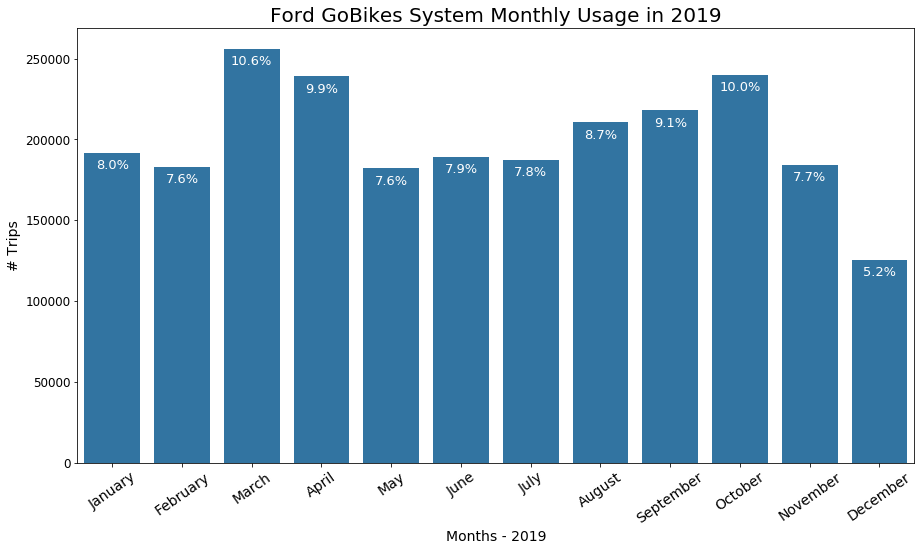

```python
base_color = sb.color_palette()[0]
plt.figure(figsize=(15,8))
sb.countplot(data=df, x='start_month',color=base_color);
plt.ylabel('# Trips',fontsize = 14)
plt.xlabel('Months - 2019',fontsize = 14)
plt.title('Ford GoBikes System Monthly Usage in 2019',fontsize = 20)
month_counts = df['start_month'].value_counts()
total_trips= month_counts.sum()
plt.yticks(size=12);
locs, labels = plt.xticks(rotation=35, size=14);
for loc, label in zip(locs, labels):
    count = month_counts[label.get_text()]
    pct_string = '{:0.1f}%'.format(100*count/total_trips)
    plt.text(loc, count-10000, pct_string, ha = 'center', color = 'white',fontsize = 13)
```

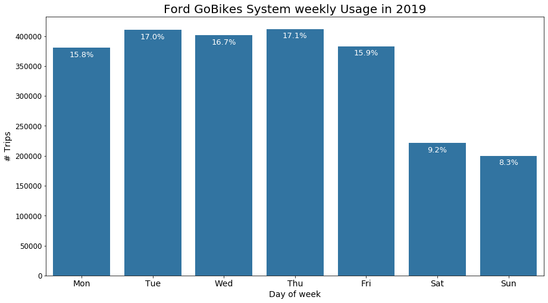

```python
plt.figure(figsize=(15,8))
daysOrder=['Mon', 'Tue', 'Wed', 'Thu', 'Fri', 'Sat', 'Sun']
sb.countplot(data=df, x='start_day_of_week',color=base_color,order=daysOrder);
plt.ylabel('# Trips',fontsize = 14)
plt.xlabel('Day of week',fontsize = 14)
plt.title('Ford GoBikes System weekly Usage in 2019',fontsize = 20)
day_counts = df['start_day_of_week'].value_counts()
total_trips= day_counts.sum()
plt.yticks(size=12);
locs, labels = plt.xticks( size=14);
for loc, label in zip(locs, labels):
    count = day_counts[label.get_text()]
    pct_string = '{:0.1f}%'.format(100*count/total_trips)
    plt.text(loc, count-15000, pct_string, ha = 'center', color = 'white',fontsize = 13)
```

> The usage drop in the weekends, so the Ford Go Bike sharing system is mainly used during the working days.

```python
df['duration_min'].describe()
```

```
count    2.407259e+06
mean     1.292218e+01
std      3.184651e+01
min      1.000000e+00
25%      5.000000e+00
50%      9.000000e+00
75%      1.400000e+01
max      1.437000e+03
Name: duration_min, dtype: float64
```

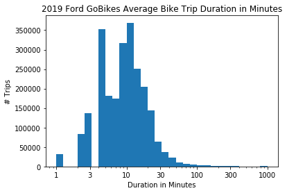

```python
bins = 10**np.arange(0 , 3 + 0.1 , 0.1)
ticks =  [ 1 , 3, 10, 30, 100, 300, 1000]
labels = ['{}'.format(t) for t in ticks]
plt.hist(data = df , x = 'duration_min' , bins = bins);
plt.xscale('log');
plt.xticks(ticks,labels);
plt.xlabel('Duration in Minutes');
plt.title('2019 Ford GoBikes Average Bike Trip Duration in Minutes');
plt.ylabel('# Trips');
```

> In 2019, the average duration of bike trips was under 12.92 minutes

[figure not shown]

```python
df['start_hour_of_day']=df['start_hour_of_day'].astype(str)
plt.figure(figsize=(20,8))
sb.countplot(data=df, x='start_hour_of_day',color=base_color,order=np.arange(0 , 24 ).astype(str));
plt.ylabel('# Trips',fontsize = 14)
plt.xlabel('Hours',fontsize = 14)
plt.title('Ford GoBikes System Hourly Start Usage in 2019',fontsize = 20)

hour_counts = df['start_hour_of_day'].value_counts()
total_trips= hour_counts.sum()
plt.yticks(size=12);
locs, labels = plt.xticks(size=14);

for loc, label in zip(locs, labels):
    count = hour_counts[label.get_text()]
    if count < 25000:
        pct_string = '{:0.1f}%'.format(100*count/total_trips)
        plt.text(loc, count+5000, pct_string, ha = 'center', color = 'black',fontsize = 13)

    else:
        pct_string = '{:0.1f}%'.format(100*count/total_trips)
        plt.text(loc, count-10000, pct_string, ha = 'center', color = 'white',fontsize = 13)
```

> The hours are mainly high to start between the morning from 8-9 and from 17-18 in the afternoon.

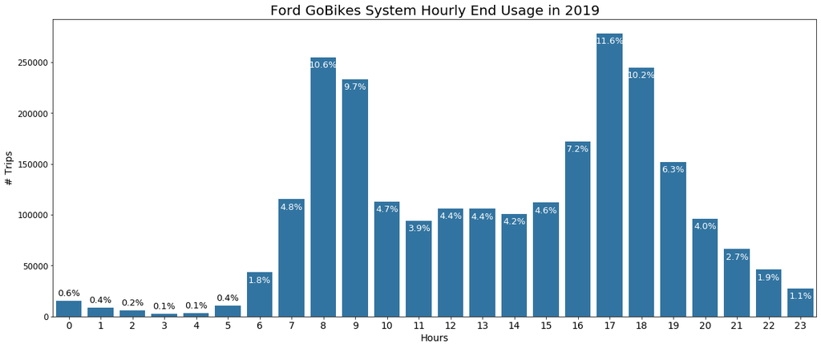

```python
df['end_hour_of_day']=df['end_hour_of_day'].astype(str)
plt.figure(figsize=(20,8))
sb.countplot(data=df, x='end_hour_of_day',color=base_color,order=np.arange(0 , 24 ).astype(str));
plt.ylabel('# Trips',fontsize = 14)
plt.xlabel('Hours',fontsize = 14)
plt.title('Ford GoBikes System Hourly End Usage in 2019',fontsize = 20)

hour_end_counts = df['end_hour_of_day'].value_counts()
total_trips= hour_counts.sum()
plt.yticks(size=12);
locs, labels = plt.xticks(size=14);

for loc, label in zip(locs, labels):
    count = hour_end_counts[label.get_text()]
    if count < 25000:
        pct_string = '{:0.1f}%'.format(100*count/total_trips)
        plt.text(loc, count+5000, pct_string, ha = 'center', color = 'black',fontsize = 13)

    else:
        pct_string = '{:0.1f}%'.format(100*count/total_trips)
        plt.text(loc, count-10000, pct_string, ha = 'center', color = 'white',fontsize = 13)
```

> The hours of end are almost the same with the start.

```python
df['distance_km'].describe()
```

```
count    2.407259e+06
mean     2.062120e+00
std      6.849460e+01
min      0.000000e+00
25%      9.317785e-01
50%      1.453611e+00
75%      2.229878e+00
max      1.279973e+04
Name: distance_km, dtype: float64
```

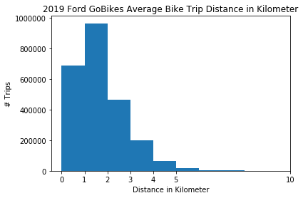

```python
bins = np.arange(0 , 10 , 1)
ticks =  [ 0 , 1, 2,3,4,5, 10]
labels = ['{}'.format(t) for t in ticks]
plt.hist(data = df , x = 'distance_km', bins=bins );
plt.xticks(ticks,labels);
plt.xlabel('Distance in Kilometer');
plt.title('2019 Ford GoBikes Average Bike Trip Distance in Kilometer');
plt.ylabel('# Trips');
```

> In 2019, the average distance of bike trips was under 2.06 kms

### Discuss the distribution(s) of your variable(s) of interest. Were there any unusual points? Did you need to perform any transformations?

> Did transformation on Duration in Minutes by log transfomation

## Bivariate Exploration

> In this section, investigate relationships between pairs of variables in your data. Make sure the variables that you cover here have been introduced in some fashion in the previous section (univariate exploration).

```python
customer = df.query('user_type == "Customer"')['bike_id'].count()
subscriber = df.query('user_type == "Subscriber"')['bike_id'].count()
customer_prop = customer / df['bike_id'].count()
subscriber_prop = subscriber / df['bike_id'].count()
```

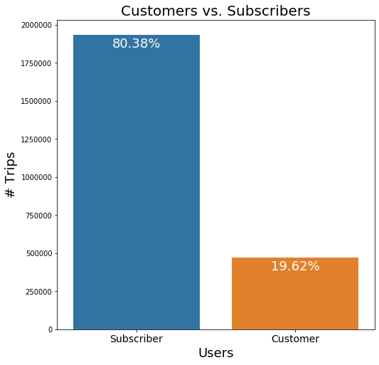

```python
plt.figure(figsize=(8,8))
sb.countplot(data = df, x = "user_type", order = df['user_type'].value_counts().index);
plt.ylabel('# Trips',fontsize = 18)
plt.xlabel('Users',fontsize = 18)
plt.title('Customers vs. Subscribers',fontsize = 20)
plt.xticks(size=14);
plt.text(0, subscriber-20000,str(round(subscriber_prop*100,2))+'%', ha = 'center',va = 'top', color = 'white',fontsize = 18)
plt.text(1, customer-20000,str(round(customer_prop*100,2))+'%', ha = 'center',va = 'top', color = 'white',fontsize = 18);
```

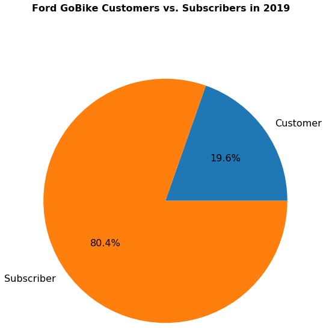

```python
plt.figure(figsize = [8, 8])
labels = ['Customer', 'Subscriber']
size = [customer_prop, subscriber_prop]
plt.pie(size, labels = labels, autopct='%1.1f%%', textprops={'color':'black','size':16})
plt.axis('equal')
plt.suptitle('Ford GoBike Customers vs. Subscribers in 2019', y=1.07,
             fontsize=16, fontweight='bold');
```

> In 2019, 80.4% of the user types in the Ford GoBikes sharing platform were Subscribers. 19.6% of the user types in the Ford GoBikes Sharing Platform were Customers.

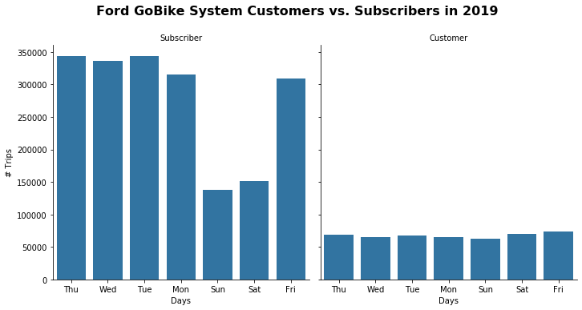

```python
plt.figure(figsize = [12, 5])
graph = sb.catplot(data=df, x='start_day_of_week',
                   col="user_type", kind='count', sharey = True,color=base_color);
graph.set_axis_labels("Days", "# Trips");
graph.set_titles("{col_name}");
graph.fig.suptitle('Ford GoBike System Customers vs. Subscribers in 2019',
                   y=1.07, fontsize=16, fontweight='bold');
graph.set_xticklabels();
```

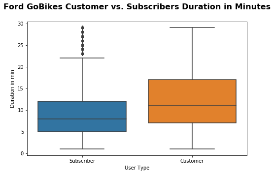

```python
plt.figure(figsize = [8, 5])
base_color = sb.color_palette()[1]
sb.boxplot(data = df.query('duration_min < 30'), x = 'user_type', y = 'duration_min')
plt.title('Ford GoBikes Customer vs. Subscribers Duration in Minutes', y=1.07, fontsize=16, fontweight='bold')
plt.xlabel('User Type')
plt.ylabel('Duration in min')
plt.show()
```

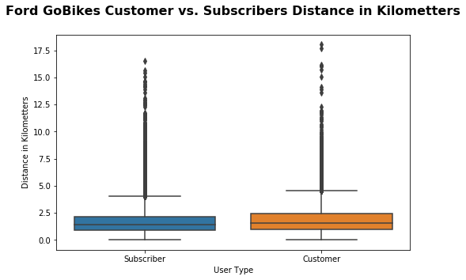

```python
plt.figure(figsize = [8, 5])
base_color = sb.color_palette()[1]
sb.boxplot(data = df.query('distance_km < 30'), x = 'user_type', y = 'distance_km')
plt.title('Ford GoBikes Customer vs. Subscribers Distance in Kilometters', y=1.07, fontsize=16, fontweight='bold')
plt.xlabel('User Type')
plt.ylabel('Distance in Kilometters')
plt.show()
```

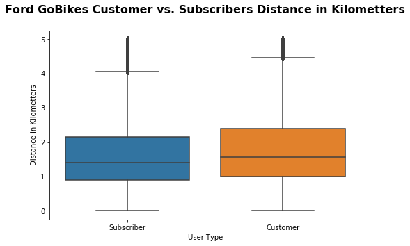

```python
plt.figure(figsize = [8, 5])
base_color = sb.color_palette()[1]
sb.boxplot(data = df.query('distance_km < 5'), x = 'user_type', y = 'distance_km')
plt.title('Ford GoBikes Customer vs. Subscribers Distance in Kilometters', y=1.07, fontsize=16, fontweight='bold')
plt.xlabel('User Type')
plt.ylabel('Distance in Kilometters')
plt.show()
```

> The Distance in Kilometters by User Type plot highlights that Customers normally have longer trip distance. Customers normally ride between 1 kilometter and 2.4 kilometter. Subscriber trips are normally shorter and last anywhere between 0.9-2.2 kilometter.

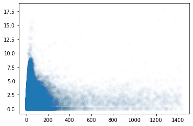

```python
df_out=df.query('distance_km < 30')
plt.scatter(y=df_out['distance_km'],x=df_out['duration_min'],alpha=0.01)
```

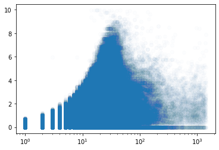

```python
df_out2=df.query('distance_km < 10 ')
plt.scatter(y=df_out2['distance_km'],x=df_out2['duration_min'],alpha=0.01)
plt.xscale('log');
```

> It shows that the data are intense in range of 0 - 8 kms and 0 - 250 min

## Multivariate Exploration

> Create plots of three or more variables to investigate your data even further. Make sure that your investigations are justified, and follow from your work in the previous sections.

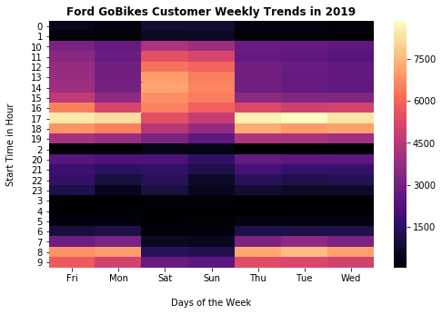

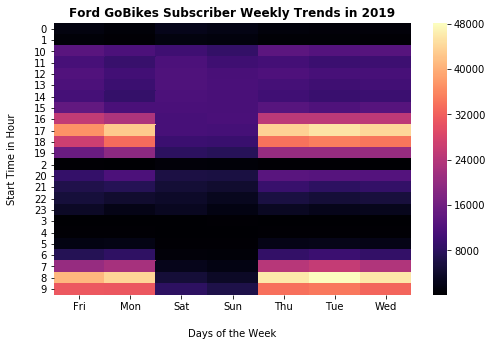

```python
plt.figure(figsize = [8, 5])
#plt.subplots(1,2)

df['start_time_weekday'] = pd.Categorical(df['start_day_of_week'],
                                                  categories= ['Mon', 'Tue', 'Wed', 'Thu', 'Fri', 'Sat', 'Sun'], ordered=True);
df_customer = df.query('user_type == "Customer"').groupby(['start_hour_of_day', 'start_day_of_week'])['bike_id'].size().reset_index();
df_customer = df_customer.pivot('start_hour_of_day', 'start_day_of_week', 'bike_id')
heat_map = sb.heatmap(df_customer, cmap = 'magma')
plt.title('Ford GoBikes Customer Weekly Trends in 2019', y=1.07, fontweight='bold')
plt.xlabel('Days of the Week', labelpad = 17)
plt.ylabel('Start Time in Hour',  labelpad = 17)
plt.show()

plt.figure(figsize = [8, 5])
df_subscriber = df.query('user_type == "Subscriber"').groupby(['start_hour_of_day', 'start_day_of_week'])['bike_id'].size().reset_index();
df_subscriber = df_subscriber.pivot('start_hour_of_day', 'start_day_of_week', 'bike_id')
heat_map = sb.heatmap(df_subscriber, cmap = 'magma')
plt.title('Ford GoBikes Subscriber Weekly Trends in 2019', y=1.07, fontweight='bold')
plt.xlabel('Days of the Week', labelpad = 17)
plt.ylabel('Start Time in Hour',  labelpad = 17)
plt.show()
```

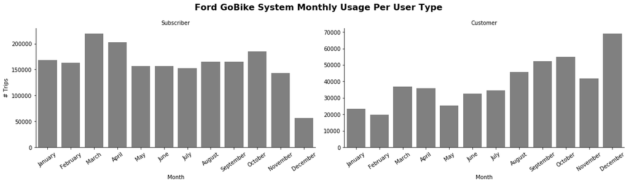

```python
graph = sb.catplot(data=df, x='start_month', col="user_type", kind='count', sharey = False, height=4, aspect=2, color='gray');
graph.set_axis_labels("Month", "# Trips")
graph.set_titles("{col_name}")
graph.fig.suptitle('Ford GoBike System Monthly Usage Per User Type', y=1.07, fontsize=16, fontweight='bold');
graph.set_xticklabels(rotation=35);
```